# Mobile device apps EDA & Data Preprocessing Project-(finalize)

## Mobile device apps EDA & Data Preprocessing Project (GLCA- DA- CHN- NOV '23) - Madhumitha.E

Week-4

## PART I:

EDA & Data Preprocessing on Google App Store Rating Dataset.

Data set Information: Web scraped data of 10k Play Store apps for analyzing the Android market. Each app (row) has values for category, rating, size, and more. Attribute Information: Slno. Attribute Description

1. App Application name
2. Category Category the app belongs to.
3. Rating Overall user rating of the app
4. Size Size of the app
5. Installs Number of user reviews for the app
6. Type Paid or Free
7. Price Price of the app
8. Content Rating Age group the app is targeted at - children/Mature 21+ /Adult
9. Genres An app can belong to multiple genres (apart from its main category). For eg. a musical family game will belong to Music, Game, Family genres.
10. Last Updated Date when the app was last updated on play store.
11. Current Ver Current version of the app available on play store.
12. Android Ver Min required Android Version.

# 1. Import required libraries and read the dataset.

```python
# importing required libraries
import pandas as pd
import numpy as np
import matplotlib.pyplot as plt
%matplotlib inline
import seaborn as sns
import sklearn as sk
import plotly.express as px
```

```python
# reading the dataset
a=pd.read_csv("Apps_data+(1) (1).csv")
df=a.copy() # creating a new variable taking the copy of the original dataframe in the new variable
df
```

|  | App | Category | Rating | Reviews | Size | Installs | Type | Price | Content Rating | Genres | Last Updated | Current Ver | Android Ver |
| --- | --- | --- | --- | --- | --- | --- | --- | --- | --- | --- | --- | --- | --- |
| 0 | Photo Editor & Candy Camera & Grid & ScrapBook | ART_AND_DESIGN | 4.1 | 159 | 19M | 10,000+ | Free | 0 | Everyone | Art & Design | January 7, 2018 | 1.0.0 | 4.0.3 and up |
| 1 | Coloring book moana | ART_AND_DESIGN | 3.9 | 967 | 14M | 500,000+ | Free | 0 | Everyone | Art & Design;Pretend Play | January 15, 2018 | 2.0.0 | 4.0.3 and up |
| 2 | U Launcher Lite – FREE Live Cool Themes, Hide ... | ART_AND_DESIGN | 4.7 | 87510 | 8.7M | 5,000,000+ | Free | 0 | Everyone | Art & Design | August 1, 2018 | 1.2.4 | 4.0.3 and up |
| 3 | Sketch - Draw & Paint | ART_AND_DESIGN | 4.5 | 215644 | 25M | 50,000,000+ | Free | 0 | Teen | Art & Design | June 8, 2018 | Varies with device | 4.2 and up |
| 4 | Pixel Draw - Number Art Coloring Book | ART_AND_DESIGN | 4.3 | 967 | 2.8M | 100,000+ | Free | 0 | Everyone | Art & Design;Creativity | June 20, 2018 | 1.1 | 4.4 and up |
| ... | ... | ... | ... | ... | ... | ... | ... | ... | ... | ... | ... | ... | ... |
| 10836 | Sya9a Maroc - FR | FAMILY | 4.5 | 38 | 53M | 5,000+ | Free | 0 | Everyone | Education | July 25, 2017 | 1.48 | 4.1 and up |
| 10837 | Fr. Mike Schmitz Audio Teachings | FAMILY | 5.0 | 4 | 3.6M | 100+ | Free | 0 | Everyone | Education | July 6, 2018 | 1.0 | 4.1 and up |
| 10838 | Parkinson Exercices FR | MEDICAL | NaN | 3 | 9.5M | 1,000+ | Free | 0 | Everyone | Medical | January 20, 2017 | 1.0 | 2.2 and up |
| 10839 | The SCP Foundation DB fr nn5n | BOOKS_AND_REFERENCE | 4.5 | 114 | Varies with device | 1,000+ | Free | 0 | Mature 17+ | Books & Reference | January 19, 2015 | Varies with device | Varies with device |
| 10840 | iHoroscope - 2018 Daily Horoscope & Astrology | LIFESTYLE | 4.5 | 398307 | 19M | 10,000,000+ | Free | 0 | Everyone | Lifestyle | July 25, 2018 | Varies with device | Varies with device |

10841 rows × 13 columns

# 2. Check the first few samples, shape, info of the data and try to familiarize yourself with different features.

```python
# checking the shape of the dataframe
df.shape
```

```
(10841, 13)
```

```python
df.size
```

```
140933
```

```python
df.sample(2)
```

|  | App | Category | Rating | Reviews | Size | Installs | Type | Price | Content Rating | Genres | Last Updated | Current Ver | Android Ver |
| --- | --- | --- | --- | --- | --- | --- | --- | --- | --- | --- | --- | --- | --- |
| 2522 | 420 BZ Budeze Delivery | MEDICAL | 5.0 | 2 | 11M | 100+ | Free | 0 | Mature 17+ | Medical | June 6, 2018 | 1.0.1 | 4.1 and up |
| 7575 | cm, mm to inch, feet converter tool | PRODUCTIVITY | 4.3 | 176 | 2.3M | 100,000+ | Free | 0 | Everyone | Productivity | September 27, 2016 | 1.1 | 2.3.3 and up |

```python
df.info()
```

```
<class 'pandas.core.frame.DataFrame'>
RangeIndex: 10841 entries, 0 to 10840
Data columns (total 13 columns):
 #   Column          Non-Null Count  Dtype
---  ------          --------------  -----
 0   App             10841 non-null  object
 1   Category        10841 non-null  object
 2   Rating          9367 non-null   float64
 3   Reviews         10841 non-null  object
 4   Size            10841 non-null  object
 5   Installs        10841 non-null  object
 6   Type            10840 non-null  object
 7   Price           10841 non-null  object
 8   Content Rating  10840 non-null  object
 9   Genres          10841 non-null  object
 10  Last Updated    10841 non-null  object
 11  Current Ver     10833 non-null  object
 12  Android Ver     10838 non-null  object
dtypes: float64(1), object(12)
memory usage: 1.1+ MB
```

Inference: The dataset contains information on mobile apps with 10,841 entries and 13 columns. The 'Rating' column has 9,367 non-null values, indicating some missing ratings. The data types include objects for categorical features and a float64 for the 'Rating' column. Additionally, other columns such as 'Type', 'Content Rating', and 'Android Ver' have a few missing values.

# 3. Check summary statistics of the dataset. List out the columns that need to be worked upon for model building.

```python
# summary statistics for all dtypes
df.describe(include="all")
```

|  | App | Category | Rating | Reviews | Size | Installs | Type | Price | Content Rating | Genres | Last Updated | Current Ver | Android Ver |
| --- | --- | --- | --- | --- | --- | --- | --- | --- | --- | --- | --- | --- | --- |
| count | 10841 | 10841 | 9367.000000 | 10841 | 10841 | 10841 | 10840 | 10841 | 10840 | 10841 | 10841 | 10833 | 10838 |
| unique | 9660 | 34 | NaN | 6002 | 462 | 22 | 3 | 93 | 6 | 120 | 1378 | 2832 | 33 |
| top | ROBLOX | FAMILY | NaN | 0 | Varies with device | 1,000,000+ | Free | 0 | Everyone | Tools | August 3, 2018 | Varies with device | 4.1 and up |
| freq | 9 | 1972 | NaN | 596 | 1695 | 1579 | 10039 | 10040 | 8714 | 842 | 326 | 1459 | 2451 |
| mean | NaN | NaN | 4.193338 | NaN | NaN | NaN | NaN | NaN | NaN | NaN | NaN | NaN | NaN |
| std | NaN | NaN | 0.537431 | NaN | NaN | NaN | NaN | NaN | NaN | NaN | NaN | NaN | NaN |
| min | NaN | NaN | 1.000000 | NaN | NaN | NaN | NaN | NaN | NaN | NaN | NaN | NaN | NaN |
| 25% | NaN | NaN | 4.000000 | NaN | NaN | NaN | NaN | NaN | NaN | NaN | NaN | NaN | NaN |
| 50% | NaN | NaN | 4.300000 | NaN | NaN | NaN | NaN | NaN | NaN | NaN | NaN | NaN | NaN |
| 75% | NaN | NaN | 4.500000 | NaN | NaN | NaN | NaN | NaN | NaN | NaN | NaN | NaN | NaN |
| max | NaN | NaN | 19.000000 | NaN | NaN | NaN | NaN | NaN | NaN | NaN | NaN | NaN | NaN |

```python
# checking if there is a null value
df.isnull().sum().sum()
```

```
1487
```

```python
# to get the null values in percentage
df.isnull().sum()/df.shape[0]*100
```

```
App                0.000000
Category           0.000000
Rating            13.596532
Reviews            0.000000
Size               0.000000
Installs           0.000000
Type               0.009224
Price              0.000000
Content Rating     0.009224
Genres             0.000000
Last Updated       0.000000
Current Ver        0.073794
Android Ver        0.027673
dtype: float64
```

Inference: The Features that are required to be worked upon for model building are : 1.Rating 2.Type 3.Content Rating 4.Current ver 5.Android ver

# 4. Check if there are any duplicate records in the dataset? if any drop them.

```python
# checking if there's duplicates present in the dataset
df.duplicated().sum()
```

```
483
```

```python
# droping the duplicates
df.drop_duplicates(inplace=True)
#Verifying whether the duplicates have been removed.
df.duplicated().sum()
```

```
0
```

# 5. Check the unique categories of the column 'Category', Is there any invalid category? If yes, drop them.

```python
# checking for the unique values in the category column
df["Category"].unique()
```

```
array(['ART_AND_DESIGN', 'AUTO_AND_VEHICLES', 'BEAUTY',
       'BOOKS_AND_REFERENCE', 'BUSINESS', 'COMICS', 'COMMUNICATION',
       'DATING', 'EDUCATION', 'ENTERTAINMENT', 'EVENTS', 'FINANCE',
       'FOOD_AND_DRINK', 'HEALTH_AND_FITNESS', 'HOUSE_AND_HOME',
       'LIBRARIES_AND_DEMO', 'LIFESTYLE', 'GAME', 'FAMILY', 'MEDICAL',
       'SOCIAL', 'SHOPPING', 'PHOTOGRAPHY', 'SPORTS', 'TRAVEL_AND_LOCAL',
       'TOOLS', 'PERSONALIZATION', 'PRODUCTIVITY', 'PARENTING', 'WEATHER',
       'VIDEO_PLAYERS', 'NEWS_AND_MAGAZINES', 'MAPS_AND_NAVIGATION',
       '1.9'], dtype=object)
```

```python
# dropping the invalid category from the category column
df.drop(df[df["Category"] == "1.9"].index, inplace=True)
#Checking whether the column with the invalid value '1.9' has been dropped.
df["Category"].unique()
```

```
array(['ART_AND_DESIGN', 'AUTO_AND_VEHICLES', 'BEAUTY',
       'BOOKS_AND_REFERENCE', 'BUSINESS', 'COMICS', 'COMMUNICATION',
       'DATING', 'EDUCATION', 'ENTERTAINMENT', 'EVENTS', 'FINANCE',
       'FOOD_AND_DRINK', 'HEALTH_AND_FITNESS', 'HOUSE_AND_HOME',
       'LIBRARIES_AND_DEMO', 'LIFESTYLE', 'GAME', 'FAMILY', 'MEDICAL',
       'SOCIAL', 'SHOPPING', 'PHOTOGRAPHY', 'SPORTS', 'TRAVEL_AND_LOCAL',
       'TOOLS', 'PERSONALIZATION', 'PRODUCTIVITY', 'PARENTING', 'WEATHER',
       'VIDEO_PLAYERS', 'NEWS_AND_MAGAZINES', 'MAPS_AND_NAVIGATION'],
      dtype=object)
```

# 6. Check if there are missing values present in the column Rating, If any? drop them and and create a new column as 'Rating_category' by converting ratings to high and low categories(>3.5 is high rest low)

```python
df["Rating"]
```

```
0        4.1
1        3.9
2        4.7
3        4.5
4        4.3
        ...
10836    4.5
10837    5.0
10838    NaN
10839    4.5
10840    4.5
Name: Rating, Length: 10357, dtype: float64
```

```python
#checking if null values are present
df["Rating"].isnull().sum()
```

```
1465
```

```python
#dropping the NaN values
#subset(Used for dropping  only the rows containing the NaN values in the "Rating" columns. Other columns with null value will be not affected)
df.dropna(subset=['Rating'], inplace=True)
# ensuring there's no null value present
df["Rating"].isnull().sum()
```

```
0
```

```python
#Creating a new column as 'Rating_category' by converting ratings to high and low categories(>3.5 is high rest low)
df["Rating_category"]=np.where(df['Rating'] > 3.5, 'High', 'Low').astype("object")
#Checking if the changes are being implemented.
df.sample(2)
```

|  | App | Category | Rating | Reviews | Size | Installs | Type | Price | Content Rating | Genres | Last Updated | Current Ver | Android Ver | Rating_category |
| --- | --- | --- | --- | --- | --- | --- | --- | --- | --- | --- | --- | --- | --- | --- |
| 3810 | JailBase - Arrests + Mugshots | NEWS_AND_MAGAZINES | 4.0 | 17240 | Varies with device | 1,000,000+ | Free | 0 | Everyone 10+ | News & Magazines | August 3, 2018 | Varies with device | 4.1 and up | High |
| 3978 | CARDI B WALLPAPERS | PERSONALIZATION | 4.1 | 8 | 4.5M | 1,000+ | Free | 0 | Everyone | Personalization | May 21, 2018 | 3.1 | 4.0.3 and up | High |

# 7. Check the distribution of the newly created column 'Rating_category' and comment on the distribution.

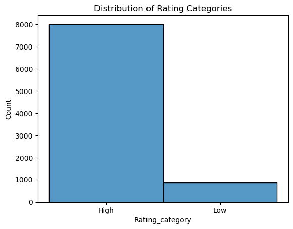

```python
#Checking the distribuation of the "Rating_category" using snsplot
sns.histplot(df['Rating_category'])
plt.title('Distribution of Rating Categories')
plt.show()
```

```python
#normalize=True(Divides the counts by the total number of observations) and multiply by 1oo for percentage
percentage_distribution = df['Rating_category'].value_counts(normalize=True) * 100
print("Percentage Distribution of Rating Categories:")
print(percentage_distribution)
```

```
Percentage Distribution of Rating Categories:
High    90.103464
Low      9.896536
Name: Rating_category, dtype: float64
```

Inference: The histogram representing the distribution of rating categories shows that the "High" category is significantly taller than the bar representing the "Low" category. This suggests that a much larger proportion of ratings falls into the "High" category, with 90% of the ratings being classified as good. The remaining 10% falls into the "Low" category.

# 8. Convert the column "Reviews'' to numeric data type and check the presence of outliers in the column and handle the outliers using a transformation approach.(Hint: Use log transformation)

```python
# changing the dtype to numeric using pd.to_numeric
#errors="coerce(if there are any errors encountered while converting values to numeric type, those values will be replaced with NaN)
df["Reviews"] = pd.to_numeric(df["Reviews"], errors="coerce")
df["Reviews"]
```

```
0           159
1           967
2         87510
3        215644
4           967
          ...
10834         7
10836        38
10837         4
10839       114
10840    398307
Name: Reviews, Length: 8892, dtype: int64
```

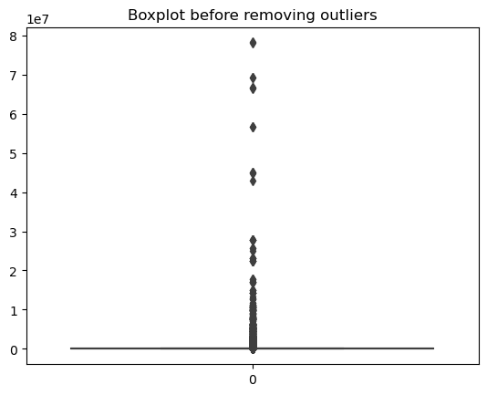

```python
# boxplot before removing outliers
sns.boxplot(df["Reviews"])
plt.title("Boxplot before removing outliers")
plt.show()
```

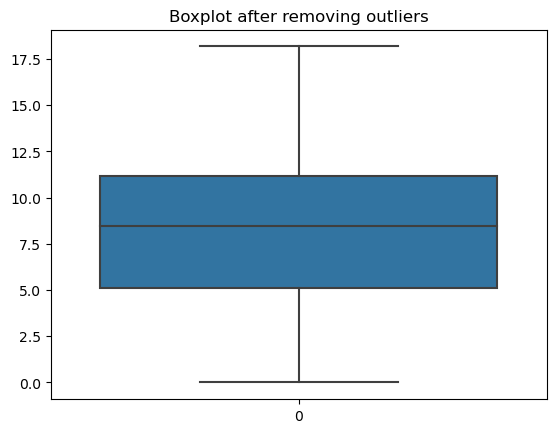

```python
# removing outlier using log transformation
df["Reviews"] = np.log(df["Reviews"])
# Check for outliers in the transformed column
sns.boxplot(df["Reviews"])
plt.title("Boxplot after removing outliers")
plt.show()
```

# 9. The column 'Size' contains alphanumeric values, treat the non numeric data and convert the column into suitable data type. (hint: Replace M with 1 million and K with 1 thousand, and drop the entries where size='Varies with device')

```python
# Displaying all the unique values in Size column
df["Size"].unique()
```

```
array(['19M', '14M', '8.7M', '25M', '2.8M', '5.6M', '29M', '33M', '3.1M',
       '28M', '12M', '20M', '21M', '37M', '2.7M', '5.5M', '17M', '39M',
       '31M', '4.2M', '23M', '6.0M', '6.1M', '4.6M', '9.2M', '5.2M',
       '11M', '24M', 'Varies with device', '9.4M', '15M', '10M', '1.2M',
       '26M', '8.0M', '7.9M', '56M', '57M', '35M', '54M', '201k', '3.6M',
       '5.7M', '8.6M', '2.4M', '27M', '2.5M', '7.0M', '16M', '3.4M',
       '8.9M', '3.9M', '2.9M', '38M', '32M', '5.4M', '18M', '1.1M',
       '2.2M', '4.5M', '9.8M', '52M', '9.0M', '6.7M', '30M', '2.6M',
       '7.1M', '22M', '6.4M', '3.2M', '8.2M', '4.9M', '9.5M', '5.0M',
       '5.9M', '13M', '73M', '6.8M', '3.5M', '4.0M', '2.3M', '2.1M',
       '42M', '9.1M', '55M', '23k', '7.3M', '6.5M', '1.5M', '7.5M', '51M',
       '41M', '48M', '8.5M', '46M', '8.3M', '4.3M', '4.7M', '3.3M', '40M',
       '7.8M', '8.8M', '6.6M', '5.1M', '61M', '66M', '79k', '8.4M',
       '3.7M', '118k', '44M', '695k', '1.6M', '6.2M', '53M', '1.4M',
       '3.0M', '7.2M', '5.8M', '3.8M', '9.6M', '45M', '63M', '49M', '77M',
       '4.4M', '70M', '9.3M', '8.1M', '36M', '6.9M', '7.4M', '84M', '97M',
       '2.0M', '1.9M', '1.8M', '5.3M', '47M', '556k', '526k', '76M',
       '7.6M', '59M', '9.7M', '78M', '72M', '43M', '7.7M', '6.3M', '334k',
       '93M', '65M', '79M', '100M', '58M', '50M', '68M', '64M', '34M',
       '67M', '60M', '94M', '9.9M', '232k', '99M', '624k', '95M', '8.5k',
       '41k', '292k', '11k', '80M', '1.7M', '10.0M', '74M', '62M', '69M',
       '75M', '98M', '85M', '82M', '96M', '87M', '71M', '86M', '91M',
       '81M', '92M', '83M', '88M', '704k', '862k', '899k', '378k', '4.8M',
       '266k', '375k', '1.3M', '975k', '980k', '4.1M', '89M', '696k',
       '544k', '525k', '920k', '779k', '853k', '720k', '713k', '772k',
       '318k', '58k', '241k', '196k', '857k', '51k', '953k', '865k',
       '251k', '930k', '540k', '313k', '746k', '203k', '26k', '314k',
       '239k', '371k', '220k', '730k', '756k', '91k', '293k', '17k',
       '74k', '14k', '317k', '78k', '924k', '818k', '81k', '939k', '169k',
       '45k', '965k', '90M', '545k', '61k', '283k', '655k', '714k', '93k',
       '872k', '121k', '322k', '976k', '206k', '954k', '444k', '717k',
       '210k', '609k', '308k', '306k', '175k', '350k', '383k', '454k',
       '1.0M', '70k', '812k', '442k', '842k', '417k', '412k', '459k',
       '478k', '335k', '782k', '721k', '430k', '429k', '192k', '460k',
       '728k', '496k', '816k', '414k', '506k', '887k', '613k', '778k',
       '683k', '592k', '186k', '840k', '647k', '373k', '437k', '598k',
       '716k', '585k', '982k', '219k', '55k', '323k', '691k', '511k',
       '951k', '963k', '25k', '554k', '351k', '27k', '82k', '208k',
       '551k', '29k', '103k', '116k', '153k', '209k', '499k', '173k',
       '597k', '809k', '122k', '411k', '400k', '801k', '787k', '50k',
       '643k', '986k', '516k', '837k', '780k', '20k', '498k', '600k',
       '656k', '221k', '228k', '176k', '34k', '259k', '164k', '458k',
       '629k', '28k', '288k', '775k', '785k', '636k', '916k', '994k',
       '309k', '485k', '914k', '903k', '608k', '500k', '54k', '562k',
       '847k', '948k', '811k', '270k', '48k', '523k', '784k', '280k',
       '24k', '892k', '154k', '18k', '33k', '860k', '364k', '387k',
       '626k', '161k', '879k', '39k', '170k', '141k', '160k', '144k',
       '143k', '190k', '376k', '193k', '473k', '246k', '73k', '253k',
       '957k', '420k', '72k', '404k', '470k', '226k', '240k', '89k',
       '234k', '257k', '861k', '467k', '676k', '552k', '582k', '619k'],
      dtype=object)
```

```python
# Dropping the entries where size='Varies with device'
df.drop(df[df["Size"] == 'Varies with device'].index, inplace=True)
df["Size"].sample(2)
```

```
2799      14M
10743    1.2M
Name: Size, dtype: object
```

```python
# Replace "M" with *1000000, "k" with *1000, remove any "+", replace ".M" with *100000, and remove any other dots
df["Size"] = df["Size"].replace({"M":"*1000000", "k": "*1000"},regex=True).map(eval)
df["Size"].sample(2)
```

```
7907    15000000.0
8916    39000000.0
Name: Size, dtype: float64
```

# 10. Check the column 'Installs', treat the unwanted characters and convert the column into a suitable data type.

```python
# Displaying the unique values in the Install column
df["Installs"].unique()
```

```
array(['10,000+', '500,000+', '5,000,000+', '50,000,000+', '100,000+',
       '50,000+', '1,000,000+', '10,000,000+', '5,000+', '100,000,000+',
       '1,000+', '500,000,000+', '100+', '500+', '10+', '1,000,000,000+',
       '5+', '50+', '1+'], dtype=object)
```

```python
#Replacing the unwanted characters in Install column
df["Installs"]=df["Installs"].replace({ r"\+": "", r"\,":""},regex=True).astype("int")
# Verifying the unwanted characters got removed
df["Installs"].head(4)
```

```
0       10000
1      500000
2     5000000
3    50000000
Name: Installs, dtype: int32
```

# 11. Check the column 'Price' , remove the unwanted characters and convert the column into a suitable data type.

```python
# Showing the unique values present in the Price column
df["Price"].unique()
```

```
array(['0', '$4.99', '$6.99', '$7.99', '$3.99', '$5.99', '$2.99', '$1.99',
       '$9.99', '$0.99', '$9.00', '$5.49', '$10.00', '$24.99', '$11.99',
       '$79.99', '$16.99', '$14.99', '$29.99', '$12.99', '$3.49',
       '$10.99', '$7.49', '$1.50', '$19.99', '$15.99', '$33.99', '$39.99',
       '$2.49', '$4.49', '$1.70', '$1.49', '$3.88', '$399.99', '$17.99',
       '$400.00', '$3.02', '$1.76', '$4.84', '$4.77', '$1.61', '$1.59',
       '$6.49', '$1.29', '$299.99', '$379.99', '$37.99', '$18.99',
       '$389.99', '$8.49', '$1.75', '$14.00', '$2.00', '$3.08', '$2.59',
       '$19.40', '$15.46', '$8.99', '$3.04', '$13.99', '$4.29', '$3.28',
       '$4.60', '$1.00', '$2.90', '$1.97', '$2.56', '$1.20'], dtype=object)
```

```python
# Renewing the unwanted character in the Price column
df["Price"]=df["Price"].replace({r"\$": ""},regex=True)
#Assuring if the unwanted character has removed
df["Price"].sample(2)
```

```
5534    0
4539    0
Name: Price, dtype: object
```

# 12. Drop the columns which you think redundant for the analysis.(suggestion: drop column 'rating', since we created a new feature from it (i.e. rating_category) and the columns 'App', 'Rating' ,'Genres','Last Updated','Current Ver','Android Ver' columns since which are redundant for our analysis)

```python
df.columns
```

```
Index(['App', 'Category', 'Rating', 'Reviews', 'Size', 'Installs', 'Type',
       'Price', 'Content Rating', 'Genres', 'Last Updated', 'Current Ver',
       'Android Ver', 'Rating_category'],
      dtype='object')
```

```python
# Dropping the columns( 'App', 'Rating' ,'Genres','Last Updated','Current Ver','Android Ver' )
df.drop(columns=['App', 'Rating', 'Genres', 'Last Updated', 'Current Ver', 'Android Ver'], inplace=True)
#examining if the columns have dropped
df.columns
```

```
Index(['Category', 'Reviews', 'Size', 'Installs', 'Type', 'Price',
       'Content Rating', 'Rating_category'],
      dtype='object')
```

# 13. Encode the categorical columns.

```python
#importing LabelEncoder from sklearn
from sklearn.preprocessing import LabelEncoder
# Identify categorical columns
catcols = df.select_dtypes(include="object").columns
# Create a LabelEncoder object
le = LabelEncoder()
# Fit and transform the entire array of categorical column names
df[catcols] = df[catcols].apply(le.fit_transform)
# checking if the values are encoded in the categorical column
df.head(10)
```

|  | Category | Reviews | Size | Installs | Type | Price | Content Rating | Rating_category |
| --- | --- | --- | --- | --- | --- | --- | --- | --- |
| 0 | 0 | 5.068904 | 19000000.0 | 10000 | 0 | 0 | 1 | 0 |
| 1 | 0 | 6.874198 | 14000000.0 | 500000 | 0 | 0 | 1 | 0 |
| 2 | 0 | 11.379508 | 8700000.0 | 5000000 | 0 | 0 | 1 | 0 |
| 3 | 0 | 12.281384 | 25000000.0 | 50000000 | 0 | 0 | 4 | 0 |
| 4 | 0 | 6.874198 | 2800000.0 | 100000 | 0 | 0 | 1 | 0 |
| 5 | 0 | 5.117994 | 5600000.0 | 50000 | 0 | 0 | 1 | 0 |
| 6 | 0 | 5.181784 | 19000000.0 | 50000 | 0 | 0 | 1 | 0 |
| 7 | 0 | 10.513661 | 29000000.0 | 1000000 | 0 | 0 | 1 | 0 |
| 8 | 0 | 9.531771 | 33000000.0 | 1000000 | 0 | 0 | 1 | 0 |
| 9 | 0 | 4.795791 | 3100000.0 | 10000 | 0 | 0 | 1 | 0 |

# 14. Segregate the target and independent features (Hint: Use Rating_category as the target)

```python
# Viewing the available columns to segregate the target and the features
df.info()
```

```
<class 'pandas.core.frame.DataFrame'>
Int64Index: 7424 entries, 0 to 10840
Data columns (total 8 columns):
 #   Column           Non-Null Count  Dtype
---  ------           --------------  -----
 0   Category         7424 non-null   int32
 1   Reviews          7424 non-null   float64
 2   Size             7424 non-null   float64
 3   Installs         7424 non-null   int32
 4   Type             7424 non-null   int32
 5   Price            7424 non-null   int32
 6   Content Rating   7424 non-null   int32
 7   Rating_category  7424 non-null   int32
dtypes: float64(2), int32(6)
memory usage: 348.0 KB
```

```python
# features are all columns excluding the "Rating_category" columns
x = df.drop("Rating_category", axis=1)
print(x)
print("\n")
# target is "Rating_category"
y = df["Rating_category"]
print(y)
```

```
       Category    Reviews        Size  Installs  Type  Price  Content Rating
0             0   5.068904  19000000.0     10000     0      0               1
1             0   6.874198  14000000.0    500000     0      0               1
2             0  11.379508   8700000.0   5000000     0      0               1
3             0  12.281384  25000000.0  50000000     0      0               4
4             0   6.874198   2800000.0    100000     0      0               1
...         ...        ...         ...       ...   ...    ...             ...
10833         3   3.784190    619000.0      1000     0      0               1
10834        11   1.945910   2600000.0       500     0      0               1
10836        11   3.637586  53000000.0      5000     0      0               1
10837        11   1.386294   3600000.0       100     0      0               1
10840        18  12.894978  19000000.0  10000000     0      0               1

[7424 rows x 7 columns]


0        0
1        0
2        0
3        0
4        0
        ..
10833    0
10834    0
10836    0
10837    0
10840    0
Name: Rating_category, Length: 7424, dtype: int32
```

# 15. Split the dataset into train and test.

```python
# features are all columns excluding the "Rating_category" columns
x = df.drop("Rating_category", axis=1)
# target is "Rating_category"
y = df["Rating_category"]

#imported the required libraries (train and test) from sklearn
# Splits the data into training and testing sets for both features and the target variable
from sklearn.model_selection import train_test_split
x_train,x_test,y_train,y_test=train_test_split(x,y)
```

# 16. Standardize the data, so that the values are within a particular range.

```python
# importing StandardScaler from sklearn
from sklearn.preprocessing import StandardScaler
# creating a standardscaler object
ss=StandardScaler()
#fit and transform
x=pd.DataFrame(ss.fit_transform(x),columns=x.columns)
x
```

|  | Category | Reviews | Size | Installs | Type | Price | Content Rating |
| --- | --- | --- | --- | --- | --- | --- | --- |
| 0 | -2.037666 | -0.679953 | -0.159928 | -0.168764 | -0.282029 | -0.225602 | -0.463220 |
| 1 | -2.037666 | -0.196531 | -0.373300 | -0.158181 | -0.282029 | -0.225602 | -0.463220 |
| 2 | -2.037666 | 1.009900 | -0.599475 | -0.060990 | -0.282029 | -0.225602 | -0.463220 |
| 3 | -2.037666 | 1.251404 | 0.096119 | 0.910911 | -0.282029 | -0.225602 | 2.517665 |
| 4 | -2.037666 | -0.196531 | -0.851254 | -0.166820 | -0.282029 | -0.225602 | -0.463220 |
| ... | ... | ... | ... | ... | ... | ... | ... |
| 7419 | -1.669089 | -1.023974 | -0.944327 | -0.168958 | -0.282029 | -0.225602 | -0.463220 |
| 7420 | -0.686217 | -1.516228 | -0.859789 | -0.168969 | -0.282029 | -0.225602 | -0.463220 |
| 7421 | -0.686217 | -1.063231 | 1.291004 | -0.168872 | -0.282029 | -0.225602 | -0.463220 |
| 7422 | -0.686217 | -1.666082 | -0.817115 | -0.168977 | -0.282029 | -0.225602 | -0.463220 |
| 7423 | 0.173797 | 1.415713 | -0.159928 | 0.046999 | -0.282029 | -0.225602 | -0.463220 |

7424 rows × 7 columns

```python
# verifying if there's null value present in both x_train and x_test
print(x_test.isnull().sum().sum())
print(x_train.isnull().sum().sum())
# importing logistic regression from sklearn
from sklearn.linear_model import LogisticRegression
# creating a logisticregression instance
logmodel = LogisticRegression(max_iter=2000)
# fitting the train's in the logestic regression
logmodel.fit(x_train,y_train)
# examining the score
logmodel.score(x_test,y_test)
```

```
0
0
```

```
0.9051724137931034
```